# Pima Indian Diabetes Data Analysis in R

Classification and prediction of diabetes disease using machine learning algorithms

Jadwiga Szkatuła

19 04 2021

## Introduction

$\qquad$ The aim of the project is to select the most effective classification method from among the selected Machine Learning techniques. Tuning the parameters will be carried out in Bagging. In the second part of the project the following models will be built on the training set:

- KKNN Weighted k-nearest neighbors Classifier (for different numbers of neighbors)
- Logit regression
- Probit regression
- Naive Bayes Classifier
- Random forest (for different number of trees)

$\qquad$ The calculations will be performed on the publicly available Prima Indians Diabetes dataset. It contains data on diabetes among 768 Indian women aged 21-81. The dataset was originally published by the National Institute of Diabetes and Digestive and Kidney Diseases.

$\qquad$ In the sample group, there was a very high ratio of diabetes, as many as 268 cases, which is almost 35% of the entire set. This is a very high result, compared to only about 10% of adult women in Poland in 2018 diagnosed with diabetes.

The dataset contains the binary variable ‘Outcome’ (1-diabetes, 0-no diabetes) and 8 health-related variables:

- Past pregnancies
- Blood pressure
- Glucose level
- The thickness of the skin fold of the triceps
- Insulin level
- BMI Index (Body Mass Index)
- Family history of diabetes
- Age

### Data Overview

| Pregnancies | Glucose | BloodPressure | SkinThickness | Insulin | BMI | Diab.Pedigree.Fun | Age | Outcome |
| --- | --- | --- | --- | --- | --- | --- | --- | --- |
| 6 | 148 | 72 | 35 | 0 | 33.6 | 0.627 | 50 | 1 |
| 1 | 85 | 66 | 29 | 0 | 26.6 | 0.351 | 31 | 0 |
| 8 | 183 | 64 | 0 | 0 | 23.3 | 0.672 | 32 | 1 |
| 1 | 89 | 66 | 23 | 94 | 28.1 | 0.167 | 21 | 0 |
| 0 | 137 | 40 | 35 | 168 | 43.1 | 2.288 | 33 | 1 |
| 5 | 116 | 74 | 0 | 0 | 25.6 | 0.201 | 30 | 0 |

|  | Mean | Std Dev | Median | Min | Max | Range | Skewness | Kurtosis |
| --- | --- | --- | --- | --- | --- | --- | --- | --- |
| Pregnancies | 3.8450521 | 3.3695781 | 3.0000 | 0.000 | 17.00 | 17.000 | 0.8981549 | 0.1421840 |
| Glucose | 120.8945312 | 31.9726182 | 117.0000 | 0.000 | 199.00 | 199.000 | 0.1730754 | 0.6193695 |
| BloodPressure | 69.1054688 | 19.3558072 | 72.0000 | 0.000 | 122.00 | 122.000 | -1.8364126 | 5.1175100 |
| SkinThickness | 20.5364583 | 15.9522176 | 23.0000 | 0.000 | 99.00 | 99.000 | 0.1089456 | -0.5309369 |
| Insulin | 79.7994792 | 115.2440024 | 30.5000 | 0.000 | 846.00 | 846.000 | 2.2633826 | 7.1331349 |
| BMI | 31.9925781 | 7.8841603 | 32.0000 | 0.000 | 67.10 | 67.100 | -0.4273073 | 3.2449627 |
| Diab.Pedigree.Fun | 0.4718763 | 0.3313286 | 0.3725 | 0.078 | 2.42 | 2.342 | 1.9124179 | 5.5285389 |
| Age | 33.2408854 | 11.7602315 | 29.0000 | 21.000 | 81.00 | 60.000 | 1.1251880 | 0.6217269 |
| Outcome | 0.3489583 | 0.4769514 | 0.0000 | 0.000 | 1.00 | 1.000 | 0.6325383 | -1.6019762 |

## Types and variables descriptions

| Variable | Description | Norm |
| --- | --- | --- |
| Pregnancies | Number of pregnancies |  |
| Glucose | Plasma glucose concentration after 2 hours in the oral glucose tolerance test | 70-140 mg/d l |
| BloodPressure | Diastolic blood pressure | 50-90 mm Hg |
| SkinThickness | Triceps skinfold thickness |  |
| Insulin | 2-hour serum insulin (µU / ml) | do 140 mU/ml, 140-199 it is pre-diabetes |
| BMI | Body mass index (weight / (height ^ 2)) | 18,5–24,9 |
| Diab.Pedigree.Fun | Diabetes prevalence rate in relatives |  |
| Age | Age |  |
| Outcome | Does the person have diabetes? |  |

|  | Pregnancies | Glucose | BloodPressure | SkinThickness | Insulin | BMI | Diab.Pedigree.Fun | Age | Outcome |
| --- | --- | --- | --- | --- | --- | --- | --- | --- | --- |
| Number of missing data | 111 | 5 | 35 | 227 | 374 | 11 | 0 | 0 | 500 |

$\qquad$ In the case of such large gaps in data in a small set, rows with gaps cannot be deleted due to too much data loss. It is always possible to replace the deficiencies with the mean or the median, but again in this case there are enough deficiencies to distort the results of later calculations. It would be reasonable to impute missing data by regression or the K-nearest neighbors method. In many studies where the authors found large gaps in data, these methods were often used instead of simply replacing the gaps with the mean or randomizing among the occurring values.

### Correlations between variables

|  | Pregnancies | Glucose | BloodPressure | SkinThickness | Insulin | BMI | Diab.Pedigree.Fun | Age | Outcome |
| --- | --- | --- | --- | --- | --- | --- | --- | --- | --- |
| Pregnancies | 1.0000000 | 0.1982910 | 0.2133548 | 0.0932094 | 0.0789836 | -0.0253473 | 0.0075621 | 0.6796085 | 0.2565660 |
| Glucose | 0.1982910 | 1.0000000 | 0.2100266 | 0.1988558 | 0.5812230 | 0.2095159 | 0.1401802 | 0.3436415 | 0.5157027 |
| BloodPressure | 0.2133548 | 0.2100266 | 1.0000000 | 0.2325712 | 0.0985115 | 0.3044034 | -0.0159711 | 0.3000389 | 0.1926733 |
| SkinThickness | 0.0932094 | 0.1988558 | 0.2325712 | 1.0000000 | 0.1821991 | 0.6643549 | 0.1604985 | 0.1677611 | 0.2559357 |
| Insulin | 0.0789836 | 0.5812230 | 0.0985115 | 0.1821991 | 1.0000000 | 0.2263965 | 0.1359058 | 0.2170820 | 0.3014292 |
| BMI | -0.0253473 | 0.2095159 | 0.3044034 | 0.6643549 | 0.2263965 | 1.0000000 | 0.1587710 | 0.0698138 | 0.2701184 |
| Diab.Pedigree.Fun | 0.0075621 | 0.1401802 | -0.0159711 | 0.1604985 | 0.1359058 | 0.1587710 | 1.0000000 | 0.0850291 | 0.2093295 |
| Age | 0.6796085 | 0.3436415 | 0.3000389 | 0.1677611 | 0.2170820 | 0.0698138 | 0.0850291 | 1.0000000 | 0.3508038 |
| Outcome | 0.2565660 | 0.5157027 | 0.1926733 | 0.2559357 | 0.3014292 | 0.2701184 | 0.2093295 | 0.3508038 | 1.0000000 |

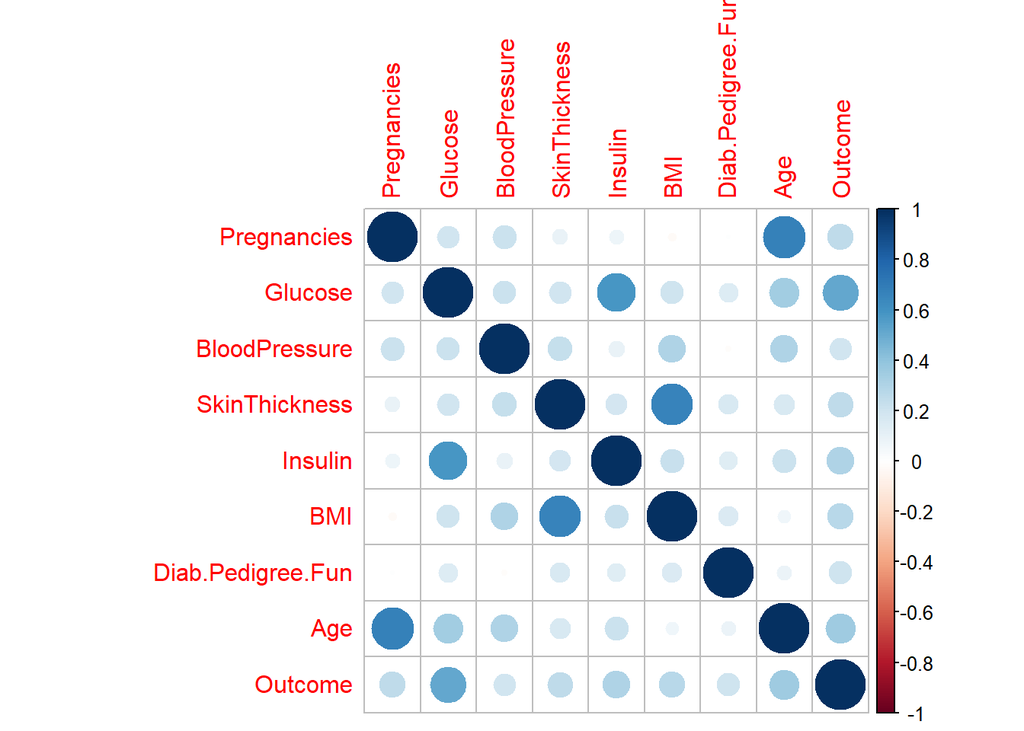

$\qquad$ Women with high glucose levels have a significantly increased risk of developing diabetes, so simply replacing the deficiencies in this variable would definitely worsen the classification results. In turn, the level of insulin and age also have the greatest influence on the result.

$\qquad$ The original data also shows a correlation between BMI and diabetes. Obesity is one of the leading causes of type II diabetes. Interestingly, the spouses of overweight women also have an increased risk of developing diabetes, possibly because women are more likely than men to be responsible for running the household (including cooking and grocery shopping). There is also a strong positive correlation between the number of pregnancies and age in the data, but this was easy to predict. In the sample group, the maximum number of pregnancies is 17, which is quite an extreme number, but due to cultural aspects, this value may not be a mistake.

### KNN Missing-data imputation

$\qquad$ The K-nearest neighbors method can be used for both classification and imputation of missing data. In both cases the algorithm works in the same way, but for classification the obtained results should be rounded to zero or one. In the case of imputation, the algorithm estimates the missing value based on the remaining variables. In the multidimensional space, it is checked what values of an unknown variable are taken by a certain number of neighbors. In this case, the number of 10 closest neighbors was used. In order to improve the accuracy, it should be checked whether a different number of neighbors gives more accurate estimates (test based on complete observations).

### The first lines after filling in the missing data

| Pregnancies | Glucose | BloodPressure | SkinThickness | Insulin | BMI | Diab.Pedigree.Fun | Age | Outcome |
| --- | --- | --- | --- | --- | --- | --- | --- | --- |
| 6 | 148 | 72.0 | 35.0 | 190.5 | 33.60 | 0.627 | 50 | 1 |
| 1 | 85 | 66.0 | 29.0 | 74.1 | 26.60 | 0.351 | 31 | 0 |
| 8 | 183 | 64.0 | 23.4 | 272.8 | 23.30 | 0.672 | 32 | 1 |
| 1 | 89 | 66.0 | 23.0 | 94.0 | 28.10 | 0.167 | 21 | 0 |
| 0 | 137 | 40.0 | 35.0 | 168.0 | 43.10 | 2.288 | 33 | 1 |
| 5 | 116 | 74.0 | 25.1 | 118.0 | 25.60 | 0.201 | 30 | 0 |
| 3 | 78 | 50.0 | 32.0 | 88.0 | 31.00 | 0.248 | 26 | 1 |
| 10 | 115 | 70.8 | 31.8 | 128.2 | 35.30 | 0.134 | 29 | 0 |
| 2 | 197 | 70.0 | 45.0 | 543.0 | 30.50 | 0.158 | 53 | 1 |
| 8 | 125 | 96.0 | 35.0 | 173.6 | 36.95 | 0.232 | 54 | 1 |

### Box plots

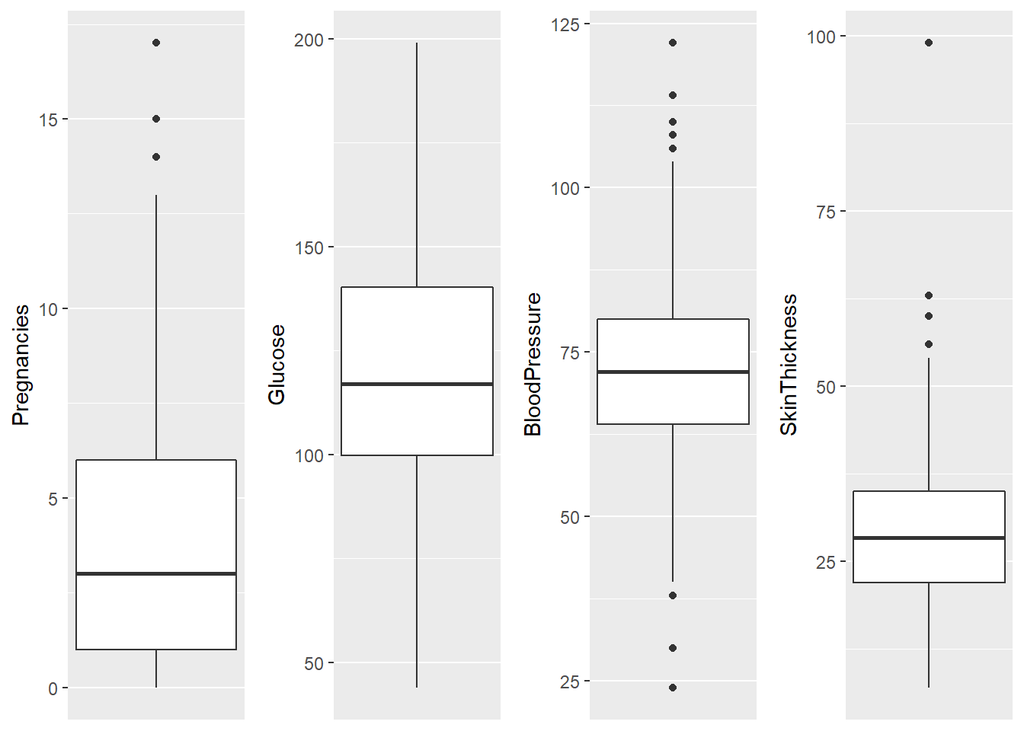

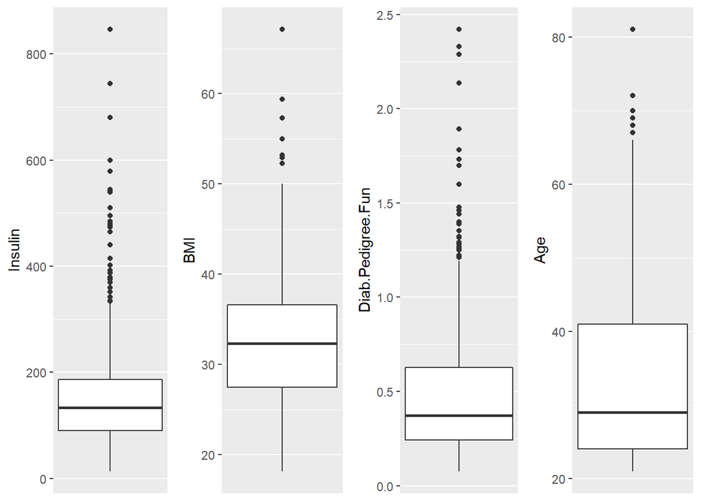

### Outliers

$\qquad$ The Mahalanobis Distance will be used to identify multivariate outliers. It is a kind of distance between two points in multidimensional space that uses standard deviations for calculations. To find outliers using Mahalanobis distance, the distance between each point and the center in the n-dimensional data is calculated and the outliers are derived from these distances. 5% of the data for which this distance is the greatest will be deleted.

| Pregnancies | Glucose | BloodPressure | SkinThickness | Insulin | BMI | Diab.Pedigree.Fun | Age | Outcome | m_dist |
| --- | --- | --- | --- | --- | --- | --- | --- | --- | --- |
| 6 | 148 | 72.0 | 35.0 | 190.5 | 33.60 | 0.627 | 50 | 1 | 2.85 |
| 1 | 85 | 66.0 | 29.0 | 74.1 | 26.60 | 0.351 | 31 | 0 | 2.87 |
| 8 | 183 | 64.0 | 23.4 | 272.8 | 23.30 | 0.672 | 32 | 1 | 8.57 |
| 1 | 89 | 66.0 | 23.0 | 94.0 | 28.10 | 0.167 | 21 | 0 | 2.29 |
| 0 | 137 | 40.0 | 35.0 | 168.0 | 43.10 | 2.288 | 33 | 1 | Outlier |
| 5 | 116 | 74.0 | 25.1 | 118.0 | 25.60 | 0.201 | 30 | 0 | 2.29 |
| 3 | 78 | 50.0 | 32.0 | 88.0 | 31.00 | 0.248 | 26 | 1 | 4.91 |
| 10 | 115 | 70.8 | 31.8 | 128.2 | 35.30 | 0.134 | 29 | 0 | 7.07 |
| 2 | 197 | 70.0 | 45.0 | 543.0 | 30.50 | 0.158 | 53 | 1 | Outlier |
| 8 | 125 | 96.0 | 35.0 | 173.6 | 36.95 | 0.232 | 54 | 1 | 5.97 |

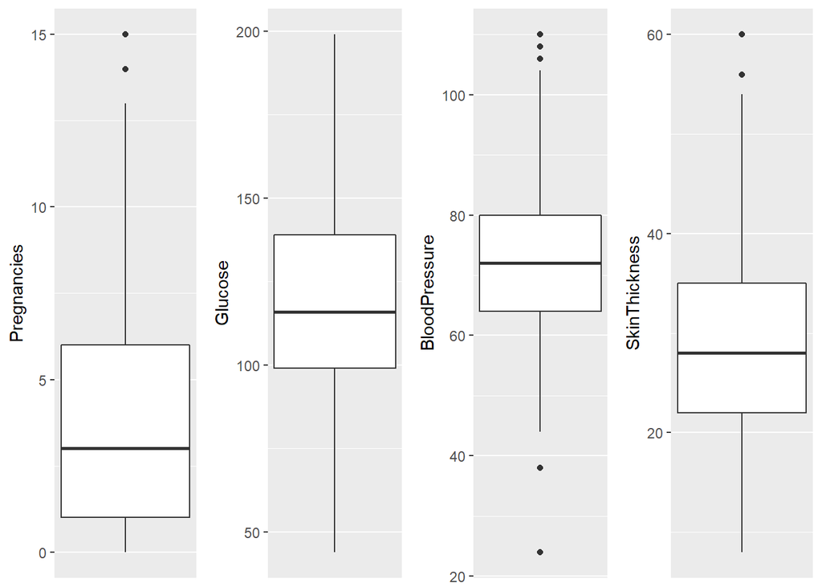

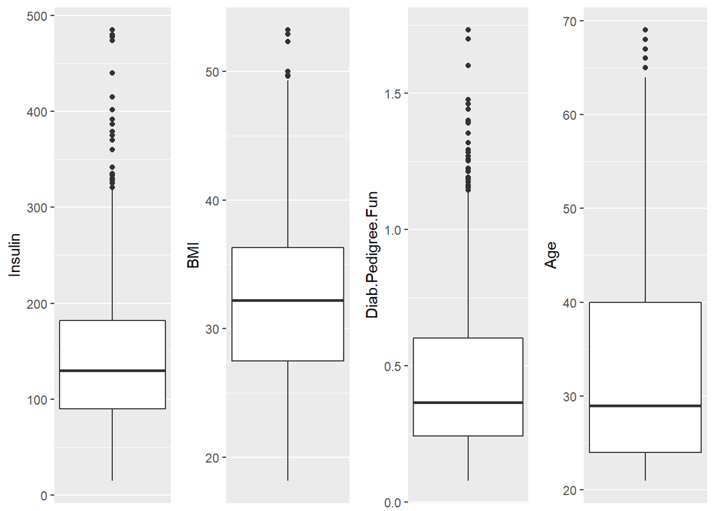

$\qquad$ After removing multivariate outliers, the box plots are more symmetrical. The observation in which the number of pregnancies was 17 has been deleted. The greatest improvement is seen in the distributions of the Insulin and Diab.Pedigree.Fun.

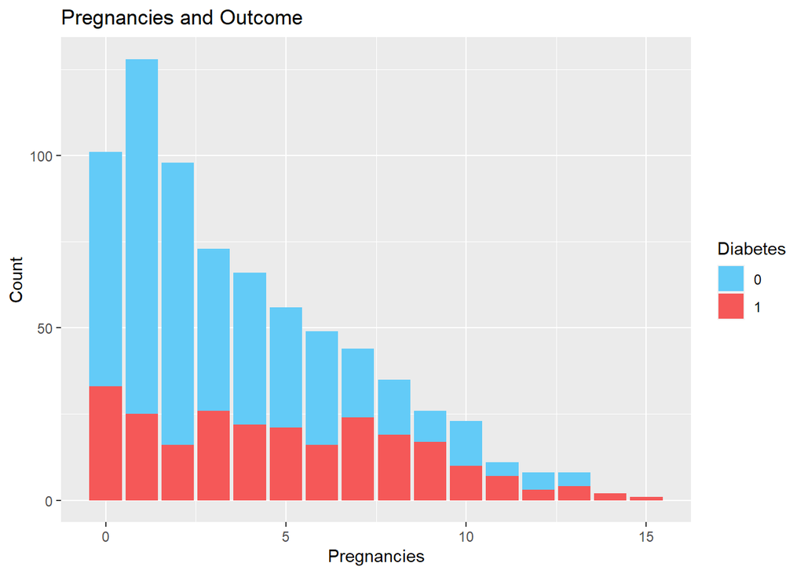

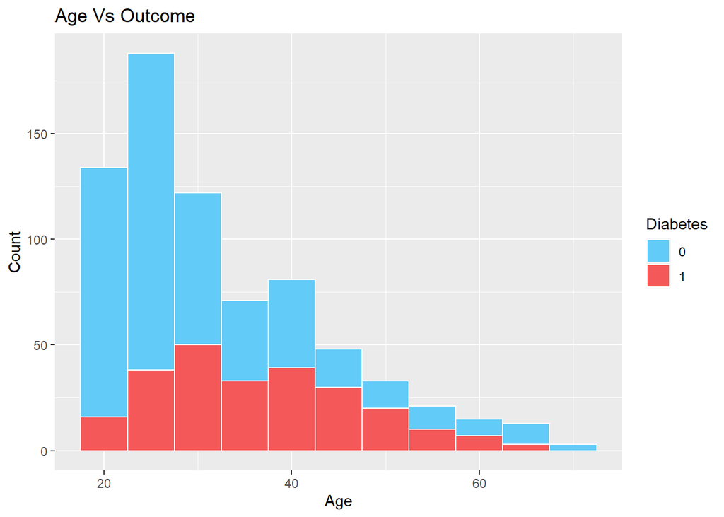

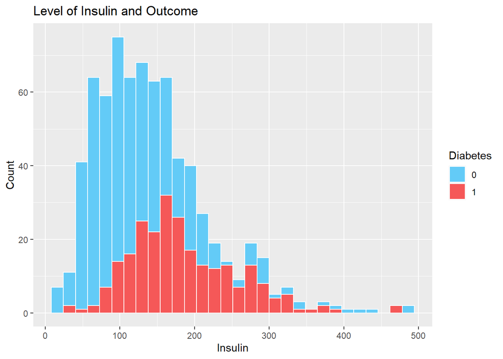

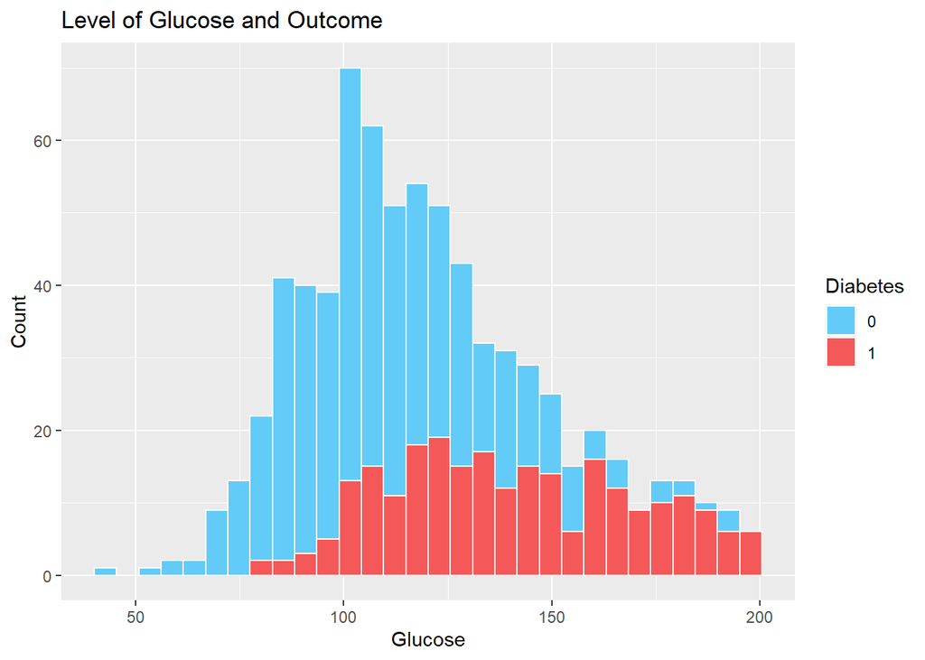

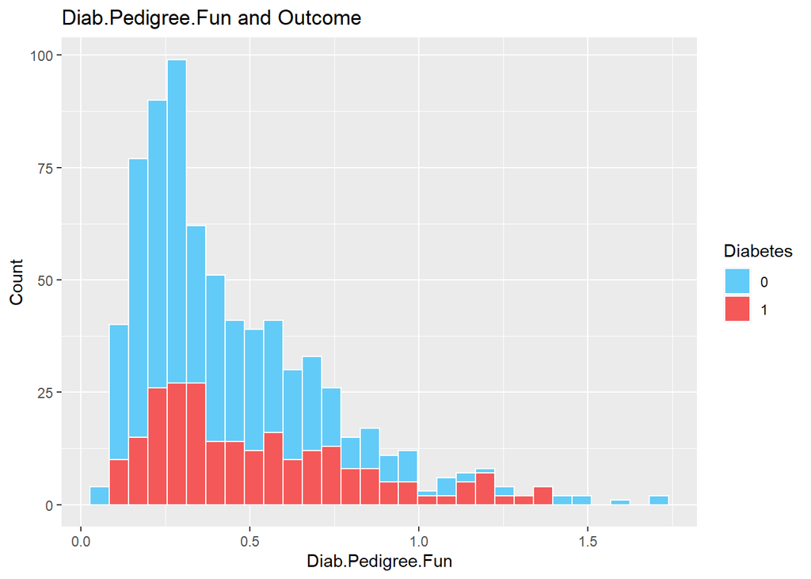

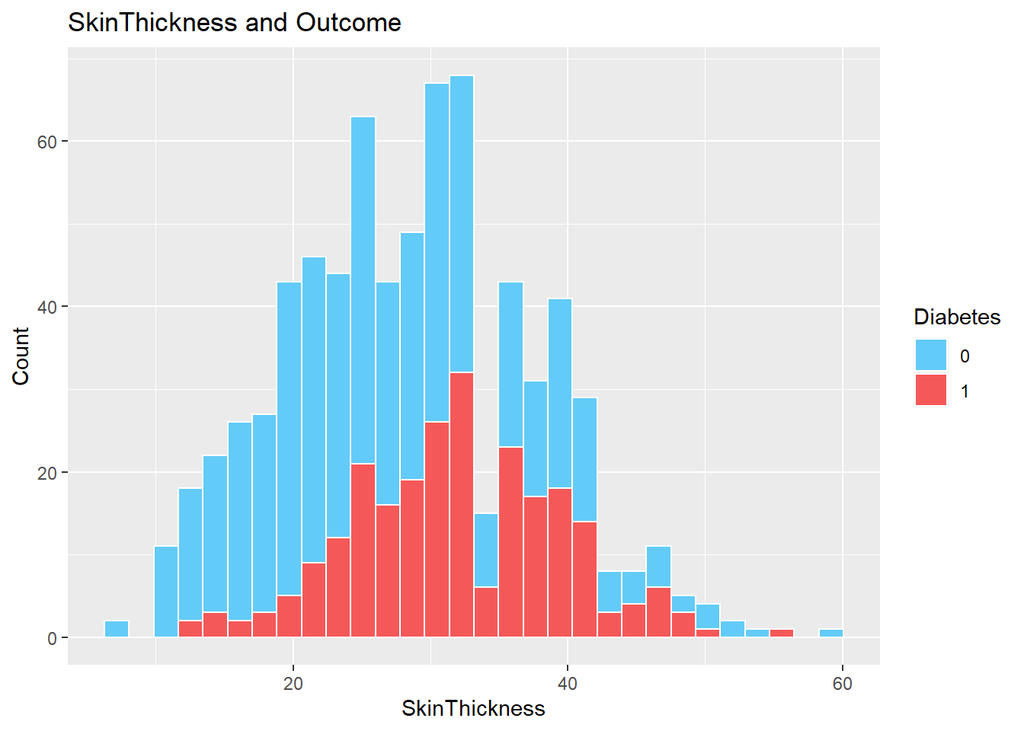

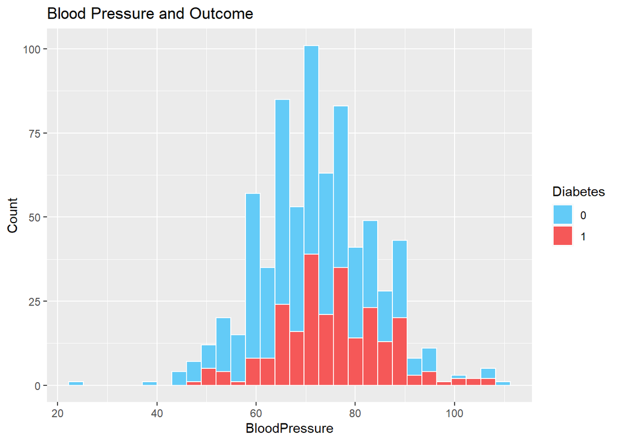

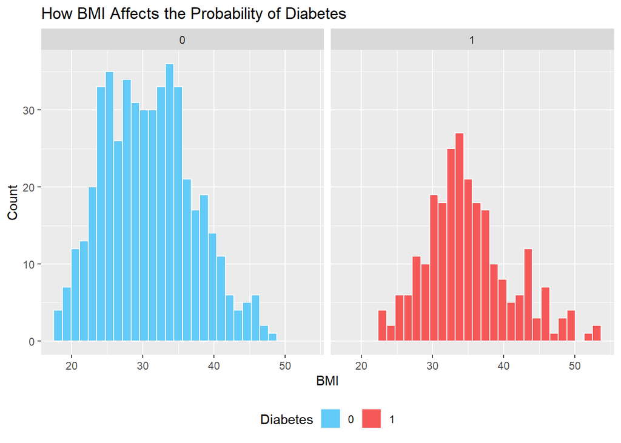

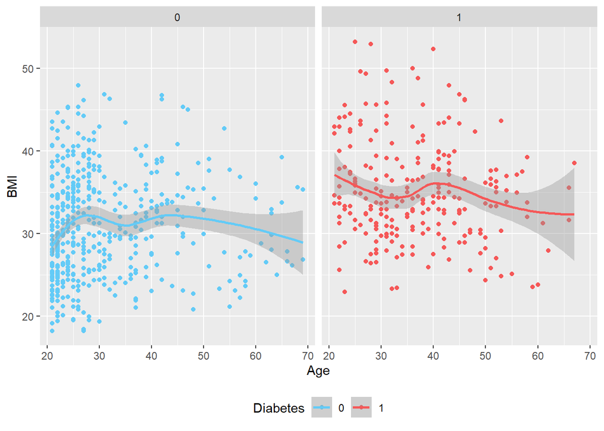

### Descriptive statistics of the training dataset

|  | Average | Standard Deviation | Median | Min | Max | Range | Skewness | Kurtosis |
| --- | --- | --- | --- | --- | --- | --- | --- | --- |
| Pregnancies | 3.7647059 | 3.3386952 | 3.00 | 0.000 | 15.000 | 15.000 | 0.8786876 | 0.0080981 |
| Glucose | 120.8041176 | 30.2561352 | 116.50 | 44.000 | 199.000 | 155.000 | 0.5624913 | -0.1621548 |
| BloodPressure | 71.9635294 | 11.3903487 | 72.00 | 24.000 | 108.000 | 84.000 | 0.0538713 | 0.5567183 |
| SkinThickness | 28.1847059 | 8.8373538 | 28.00 | 10.000 | 60.000 | 50.000 | 0.2576642 | -0.2458449 |
| Insulin | 143.0711765 | 77.6450572 | 130.00 | 15.000 | 485.000 | 470.000 | 1.1765551 | 2.0476488 |
| BMI | 31.9315294 | 6.3950519 | 32.00 | 18.200 | 53.200 | 35.000 | 0.3628517 | 0.0121131 |
| Diab.Pedigree.Fun | 0.4553373 | 0.2942893 | 0.37 | 0.085 | 1.731 | 1.646 | 1.4215656 | 2.2607296 |
| Age | 32.7843137 | 11.3513520 | 29.00 | 21.000 | 69.000 | 48.000 | 1.1064671 | 0.4939597 |
| Outcome | 0.3352941 | 0.4725567 | 0.00 | 0.000 | 1.000 | 1.000 | 0.6957173 | -1.5189443 |

### Descriptive statistics of the test dataset

|  | Average | Standard Deviation | Median | Min | Max | Range | Skewness | Kurtosis |
| --- | --- | --- | --- | --- | --- | --- | --- | --- |
| Pregnancies | 4.0045662 | 3.2033493 | 3.000 | 0.000 | 14.000 | 14.00 | 0.7851859 | -0.1083621 |
| Glucose | 119.6776256 | 28.5574265 | 115.000 | 56.000 | 189.000 | 133.00 | 0.5705439 | -0.2366336 |
| BloodPressure | 72.3817352 | 11.7882399 | 72.000 | 44.000 | 110.000 | 66.00 | 0.1816840 | 0.2057073 |
| SkinThickness | 29.2607306 | 9.1620483 | 29.000 | 8.000 | 54.000 | 46.00 | 0.1072801 | -0.2838559 |
| Insulin | 146.4287671 | 74.3037607 | 134.200 | 23.000 | 480.000 | 457.00 | 1.2834992 | 2.2274362 |
| BMI | 33.0008676 | 6.6402437 | 32.900 | 18.200 | 52.900 | 34.70 | 0.2809935 | -0.3883904 |
| Diab.Pedigree.Fun | 0.4477078 | 0.2879859 | 0.349 | 0.078 | 1.318 | 1.24 | 1.1208902 | 0.5273962 |
| Age | 32.4977169 | 10.8688489 | 29.000 | 21.000 | 69.000 | 48.00 | 1.0462702 | 0.3937580 |
| Outcome | 0.3424658 | 0.4756216 | 0.000 | 0.000 | 1.000 | 1.00 | 0.6594104 | -1.5722949 |

### Comparison of the distributions of variables in the test and training dataset

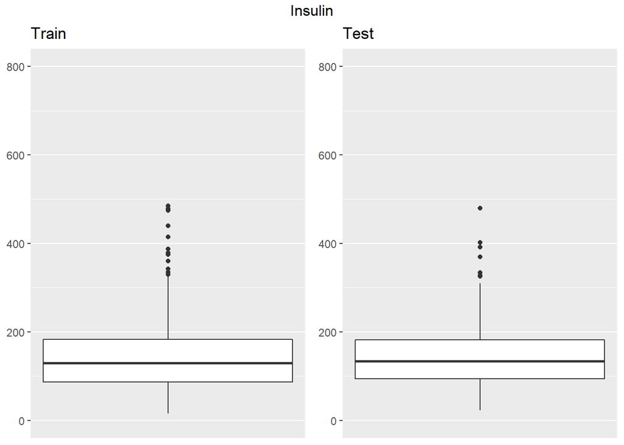

[figure not shown]

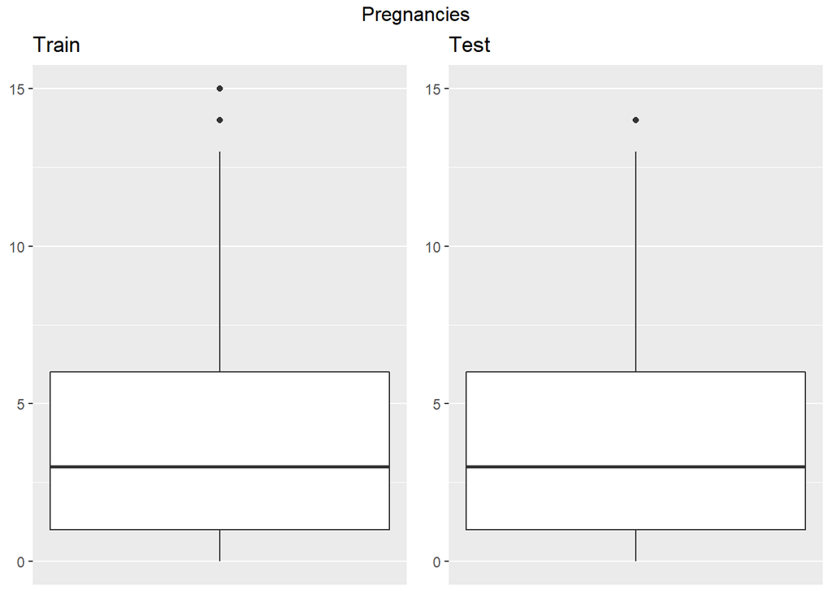

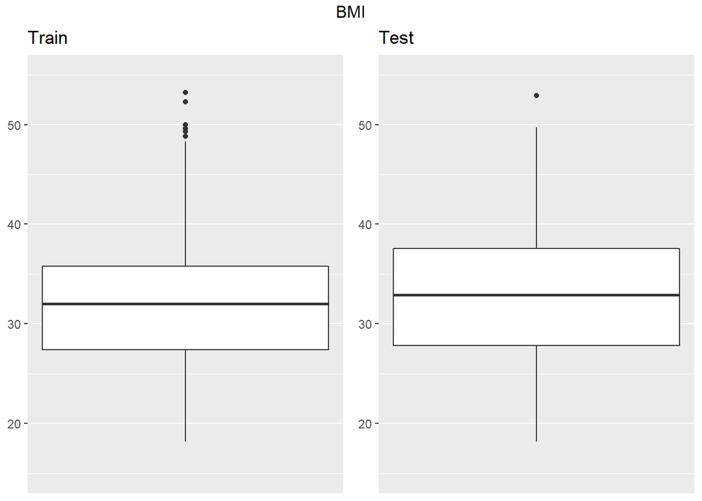

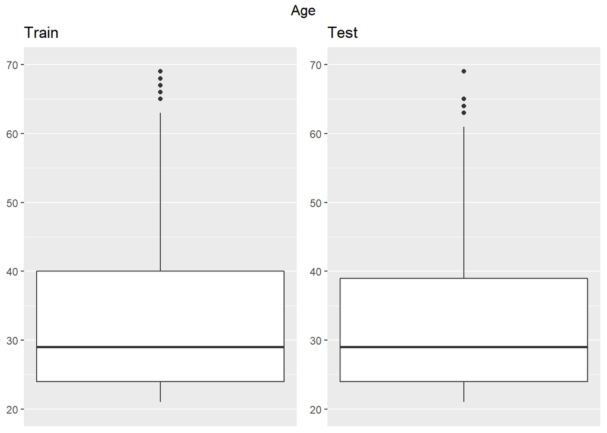

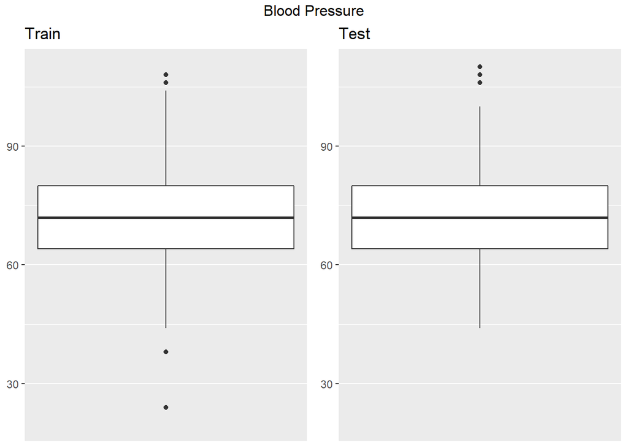

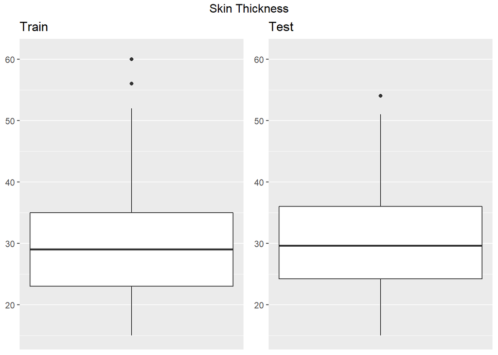

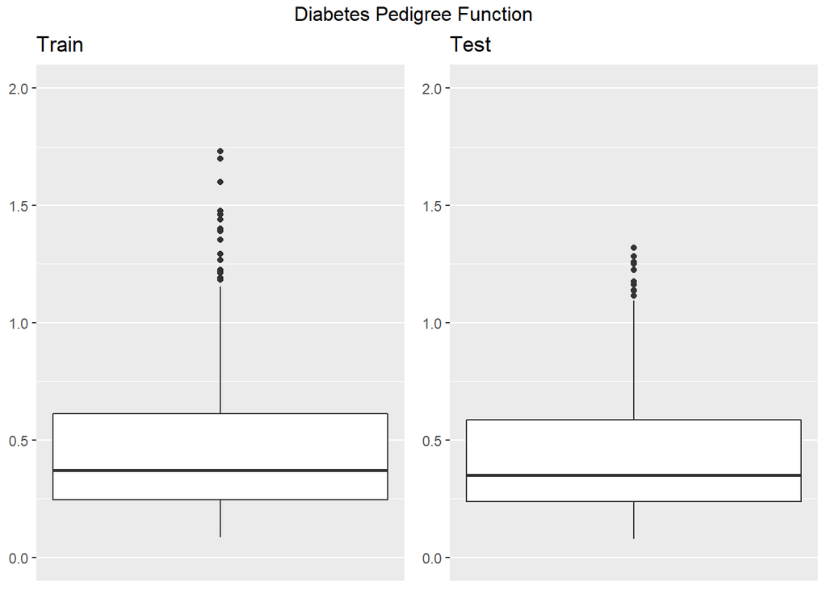

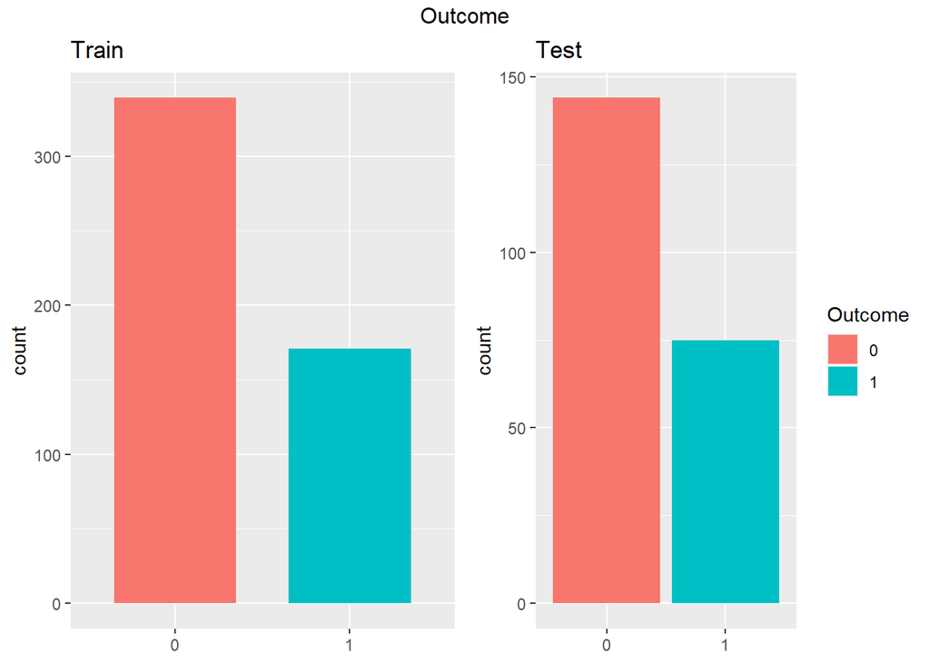

$\qquad$ The distributions of the variables are similar in both sets. Variables from the training set usually take a slightly larger range, but this is due to the greater size of this set.

$\qquad$ After the division, it should be checked whether the descriptive statistics in both subsets are similar. They are similar for this division. In the case of categorical variables, it should also be checked whether all the values appear in the training set. Otherwise, some algorithms would not be able to cope with the classification.

## Parameters Tuning

### Decision Tree

$\qquad$ It is a decision support tool and one of the most commonly used data analysis techniques. The tree consists of a root, branches and nodes. In this flowchart-like structure each internal node represents a test on an attribute, each branch represents the outcome of the test, and each leaf node represents a class label. The paths from root to leaf represent classification rules.

Decision trees are divided into:

• Regression trees - the explained variable is continuous • Classification trees - the explained variable is discrete

Benefits:

- They are very clear and easy to interpret, the algorithm is similar to human decision making
- They perform well with qualitative data, and data gaps are not a problem for them

Defects:

- Instability - with few data changes, the tree structure can change completely
- Ability to parameterize - overfitting, then the effectiveness on the training set is very high, but on the test set it is much worse

In R, the rpart () function from the package of the same name is used to create the tree.

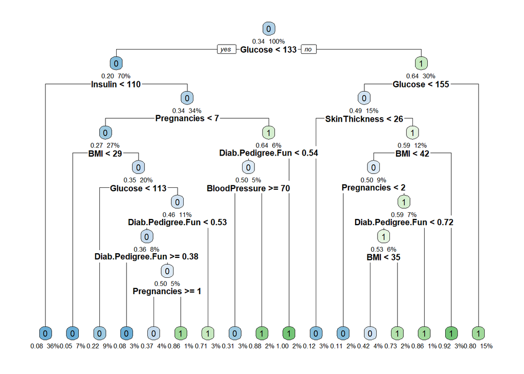

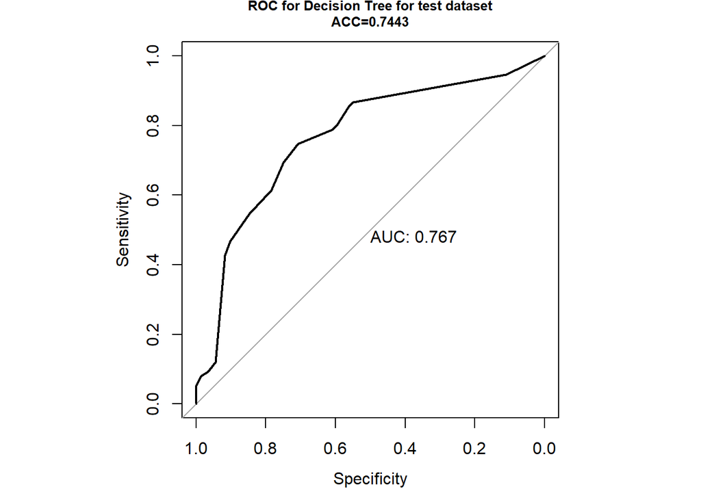

### Bagging

$\qquad$Bagging is a method that avoids the disadvantage of a single tree, which is instability. It creates many decision trees and average the results. In order for the trees to differ from each other, a percentage of observations from the training set is selected, about 60-70%. Increasing the number of trees gives better and better results, but the increase in accuracy decreases. The parameters that can be manipulated are therefore the number of trees and the percentage of the test set. In the algorithm different values were tested to see when the accuracy would be highest.

1. Testing a different number of trees - changing the “nbagg” parameter

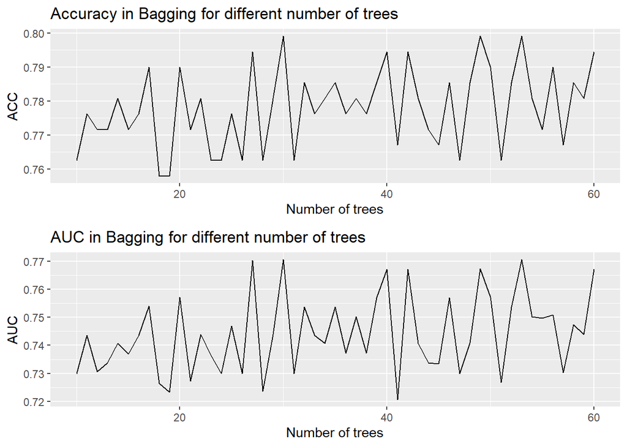

2. Testing a different percentage of the training set to create each tree - changing the “ns” parameter

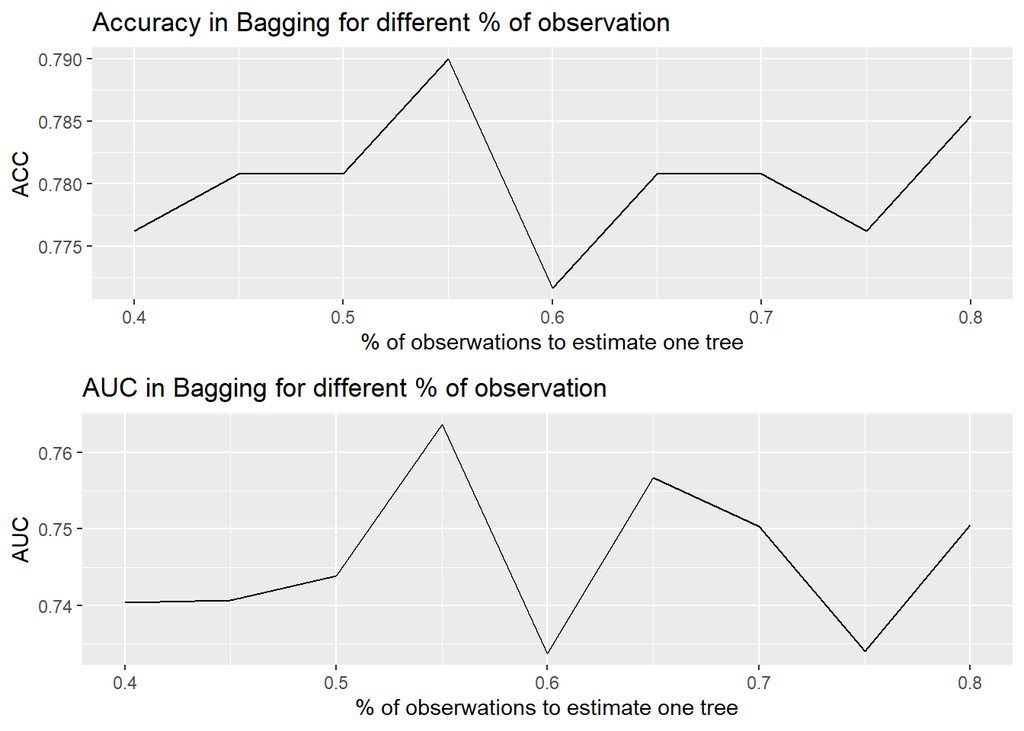

$\qquad$ In this case, the highest accuracy and AUC were obtained for randomizing 55% of the observations from the training set. The differences in the obtained results are significant, which means that for this data set, the selection of a specific percent of the data to build each tree is important.

3. Changing the number of trees and the “ns” parameter

```
##                                      Method   ACC   AUC
## 1 Bagging number of trees =  25  %obs = 0.7 0.817 0.791
```

| Method | ACC | AUC |
| --- | --- | --- |
| Bagging number of trees = 25 %obs = 0.7 | 0.817 | 0.791 |

$\qquad$ The best result after tuning the number of trees and nb parameter in bagging was obtained for 25 trees with 70% observations. Accuracy on the test dataset is 81.7%, and AUC equals 0.791.

### KKNN The Weighted Nearest Neighbour Classifier

$\qquad$ In this method, for each object, k of its closest neighbors are determined (according to Minkowski’s distance), and then the result is determined based on the voice of the majority of these objects. The weight of votes depends on the distance of the neighbors from the selected object, the smaller it is, the higher the value of the vote. A different number of neighbors ranging from 3-50 will be tested.

## ROC Curves for chosen number of neighbors in KKNN

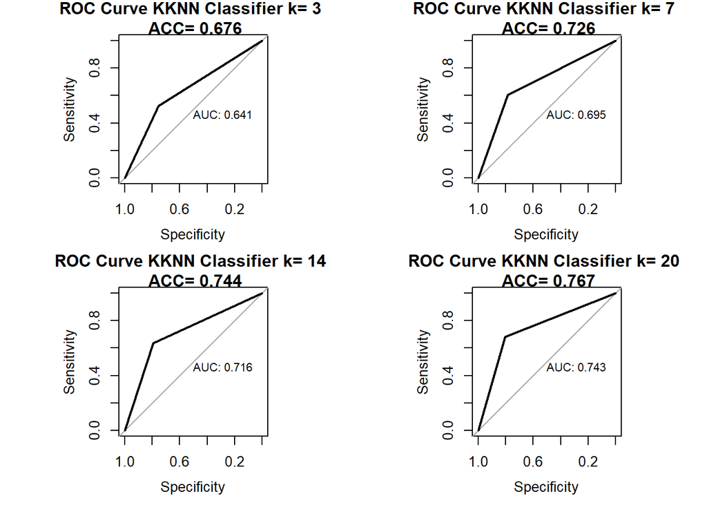

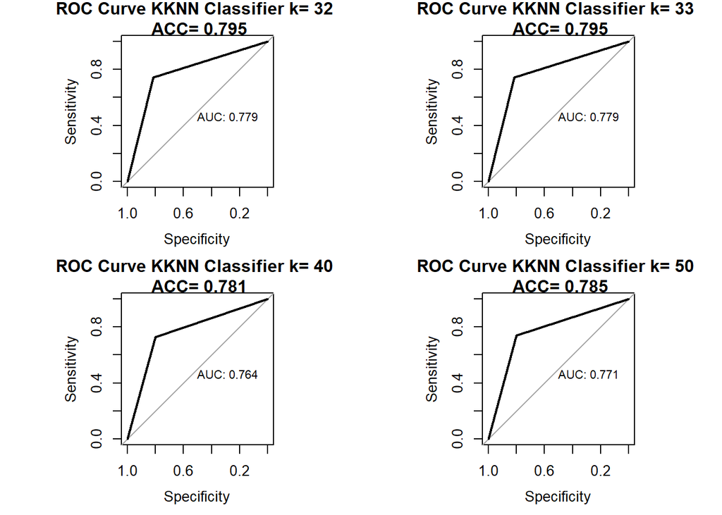

[figure not shown]

The best results in the KKNN were obtained for 32 and 33 neighbors. The accuracy is then 0.795 and AUC = 0.779.

### Naive Bayes Classifier

$\qquad$ It is a method that answers the question of what is the probability that an object belongs to a given class as long as it has certain characteristics. In this case, what is the likelihood that a person has diabetes, given the age, glucose, and other health parameters of a person. This can be represented by the equation:

$$P(C|X)=\frac{P(X|C)*P(C)}{P(X)}$$
Where:

- $P(C|X)$ is the posterior probability of class (target) given predictor (attribute)
- $P(X|C)$ is the likelihood which is the probability of predictor given class
- $P(C)$ is the prior probability of class
- $P(X)$ is the prior probability of predictor

The “naivety” of the classifier comes from the fact that it assumes the independence of the variables describing a given observation.

```
## Confusion Matrix and Statistics
##
##           Reference
## Prediction   0   1
##          0 120  23
##          1  24  52
##
##                Accuracy : 0.7854
##                  95% CI : (0.725, 0.8378)
##     No Information Rate : 0.6575
##     P-Value [Acc > NIR] : 2.462e-05
##
##                   Kappa : 0.525
##
##  Mcnemar's Test P-Value : 1
##
##             Sensitivity : 0.8333
##             Specificity : 0.6933
##          Pos Pred Value : 0.8392
##          Neg Pred Value : 0.6842
##              Prevalence : 0.6575
##          Detection Rate : 0.5479
##    Detection Prevalence : 0.6530
##       Balanced Accuracy : 0.7633
##
##        'Positive' Class : 0
##
```

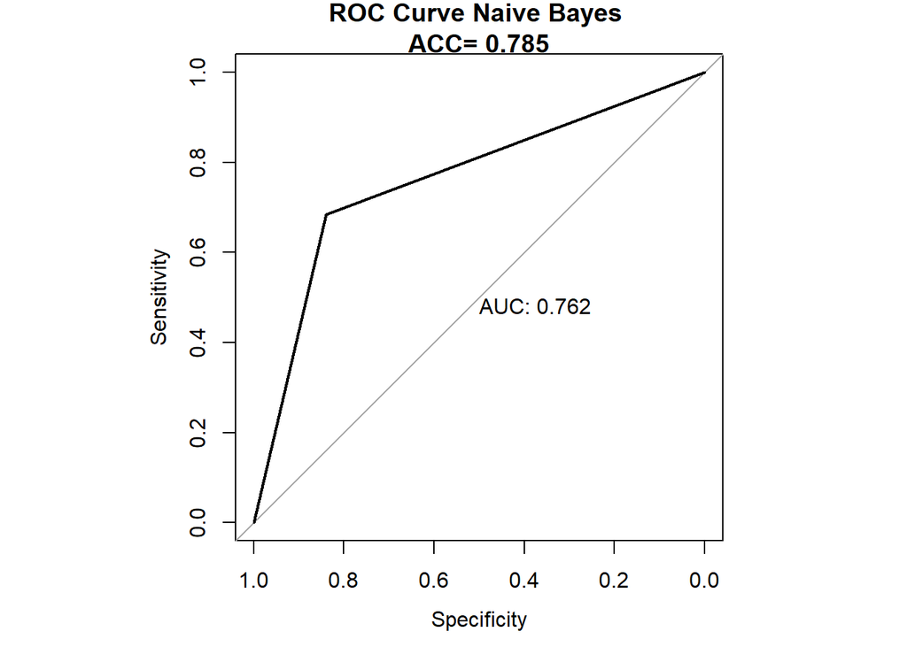

$\qquad$ Despite its “naivety”, the classifier did quite well at predicting the values of the test dataset. The accuracy was 78.5% and the AUC equals 0.762.

### Logit Model

$\qquad$ The logit model is used to model data in which the variable being explained is a binary variable. In the logit model, the cumulative distribution function of the logistic function is used to transform the values into those from the interval (0,1), and in the probit model, the cumulative normal distribution function is used. These functions are similar to each other, with the logit function having thinner tails than the normal distribution.

If $log(\frac{Y}{1-Y})=X\beta$, to $Y=\frac{e^{X\beta}}{1+e^{X\beta}}$

Parameters could be interpreted using odds ratio:

$\frac{p_{i}}{1-p_{i}}=e^{\beta_{0}+\beta_{1}x_{1,i}+...+\beta_{k}x_{k,i}}$

If the value x1 had increased by a unit, then:

$e^{\beta_{0}+\beta_{1}(x_{1,i}+1)+...+\beta_{k}x_{k,i}}=e^{\beta_{0}+\beta_{1}x_{1,i}+...+\beta_{k}x_{k,i}}e^{\beta_{1}}$

The positive sign of the parameter says that the increase of the variable increases the probability of the variable y assuming the value 1. (Negative sign: the increase of the variable increases the probability of the value 0).

```
##
## Call:
## glm(formula = Outcome ~ ., family = "binomial", data = train)
##
## Deviance Residuals:
##     Min       1Q   Median       3Q      Max
## -2.6894  -0.7216  -0.3862   0.6744   2.4214
##
## Coefficients:
##                    Estimate Std. Error z value Pr(>|z|)
## (Intercept)       -9.730620   1.087319  -8.949  < 2e-16 ***
## Pregnancies        0.105662   0.042293   2.498  0.01248 *
## Glucose            0.040624   0.005753   7.061 1.65e-12 ***
## BloodPressure     -0.004449   0.011613  -0.383  0.70164
## SkinThickness      0.015342   0.019001   0.807  0.41942
## Insulin           -0.001200   0.002027  -0.592  0.55390
## BMI                0.092679   0.028641   3.236  0.00121 **
## Diab.Pedigree.Fun  1.071926   0.383869   2.792  0.00523 **
## Age                0.002554   0.012858   0.199  0.84257
## ---
## Signif. codes:  0 '***' 0.001 '**' 0.01 '*' 0.05 '.' 0.1 ' ' 1
##
## (Dispersion parameter for binomial family taken to be 1)
##
##     Null deviance: 650.62  on 509  degrees of freedom
## Residual deviance: 464.37  on 501  degrees of freedom
## AIC: 482.37
##
## Number of Fisher Scoring iterations: 5
```

```
## Confusion Matrix and Statistics
##
##           Reference
## Prediction   0   1
##          0 126  31
##          1  18  44
##
##                Accuracy : 0.7763
##                  95% CI : (0.7152, 0.8297)
##     No Information Rate : 0.6575
##     P-Value [Acc > NIR] : 8.831e-05
##
##                   Kappa : 0.4817
##
##  Mcnemar's Test P-Value : 0.08648
##
##             Sensitivity : 0.8750
##             Specificity : 0.5867
##          Pos Pred Value : 0.8025
##          Neg Pred Value : 0.7097
##              Prevalence : 0.6575
##          Detection Rate : 0.5753
##    Detection Prevalence : 0.7169
##       Balanced Accuracy : 0.7308
##
##        'Positive' Class : 0
##
```

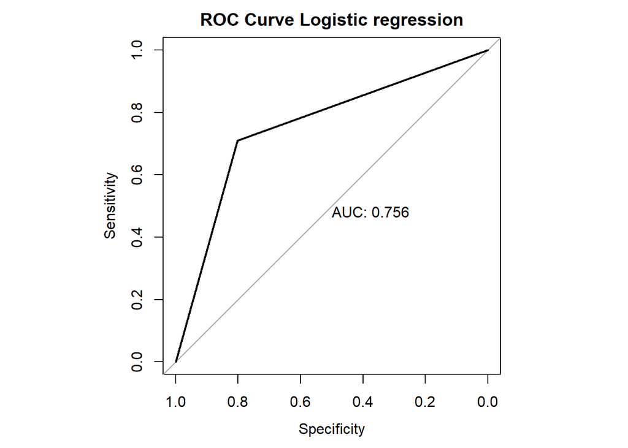

```
##
## Call:
## roc.default(response = factor(round(predict(log_model, newdata = test,     type = "response"), 0)), predictor = test$Outcome, plot = TRUE,     print.auc = TRUE, main = "ROC Curve Logistic regression")
##
## Data: test$Outcome in 157 controls (factor(round(predict(log_model, newdata = test, type = "response"), 0)) 0) < 62 cases (factor(round(predict(log_model, newdata = test, type = "response"), 0)) 1).
## Area under the curve: 0.7561
```